# Лабораторная работа №5

Дисциплина - Операционные Системы

Азарцова В. В.

Российский университет дружбы народов, Москва, Россия

Преподаватель Кулябов Д. С.

13 марта 2025

# Информация

## Докладчик

- Азарцова Вероника Валерьевна
- НКАбд-01-24, студ. билет №1132246751
- Российский университет дружбы народов
- 1132246751@pfur.ru
- https://github.com/vvazarcova

## Цели работы

Цели данной лабораторной работы:

- Научиться пользоваться менеджером пароля pass
- Научиться пользоваться chezmoi

## Задачи

- Установить менеджер паролей pass
- Настроить менеджер паролей pass
- Настроить интерфейс с броузером
- Установить дополнительное программное обеспечение
- Использовать chezmoi

## Теоретическое введение

Менеджер паролей pass — программа, сделанная в рамках идеологии Unix. Также носит название стандартного менеджера паролей для Unix (The standard Unix password manager).  
Данные хранятся в файловой системе в виде каталогов и файлов. Файлы шифруются с помощью GPG-ключа.

# Выполнение лабораторной работы

## Менеджер паролей pass

Устанавливаю pass.

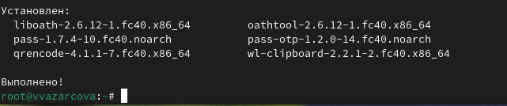

Установка pass

## Менеджер паролей pass

Устанавливаю gopass.

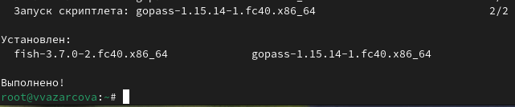

Установка gopass

## Менеджер паролей pass

Вывожу список ключей, нахожу id моего ключа, и использую его чтобы инициализировать хранилище.

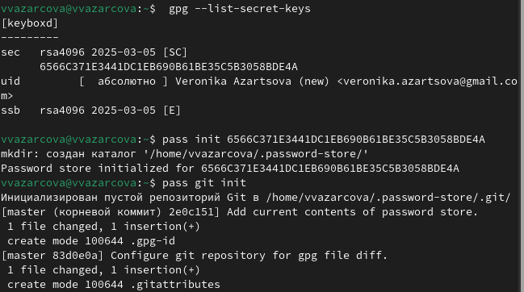

Инициализация хранилища

## Менеджер паролей pass

Создаю структуру git и задаю адрес репозитория на хостинге, предварительно создав его и назвав его git-new.

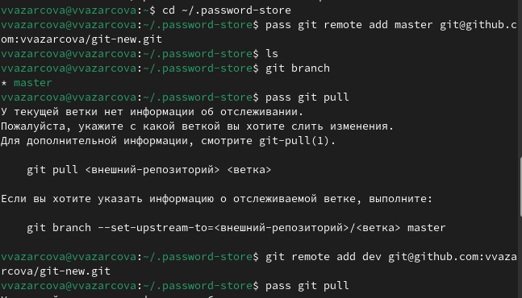

Создание структуры git

## Менеджер паролей pass

Синхронизирую с помощью команд pass git pull и push.

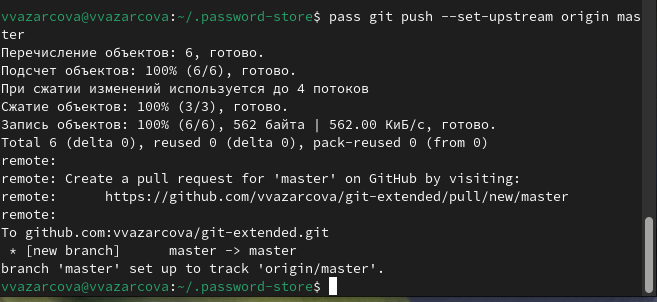

Синхронизация

## Менеджер паролей pass

Изменения сделаны непосредственно на файловой системе, следовательно вручную добавляю в коммит и выкладываю изменения.

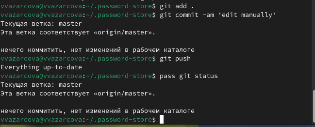

Ручная правка

## Настройка интерфейса с броузером

Устанавливаю интерфейс для взаимодействия с броузером (native messaging).

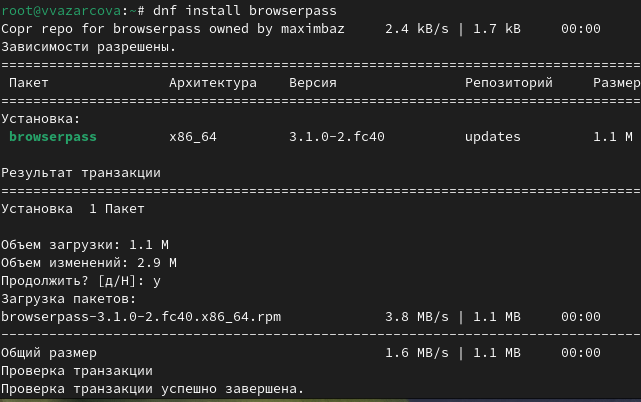

## Сохранение пароля

Добавляю новый пароль.

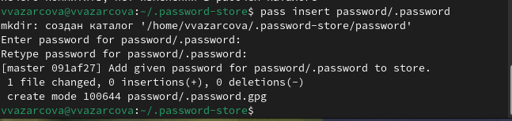

Новый пароль

## Дополнительное программное обеспечение

Устанавливаю дополнительное программное обеспечение.

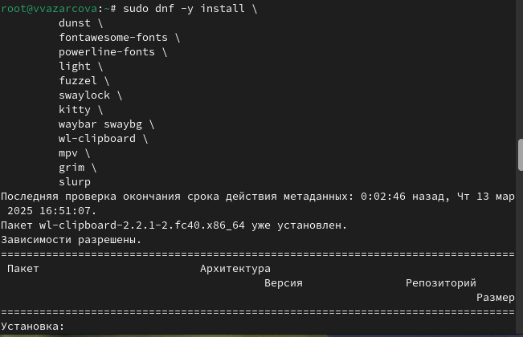

Установка дополнительного программного обеспечения

## Дополнительное программное обеспечение

Устанавливаю шрифты.

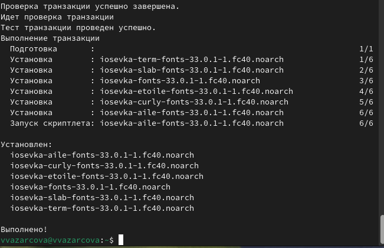

Установка шрифтов

## Chezmoi

Создаю репозиторий и подключаю его к своей системе с помощью chezmoi.

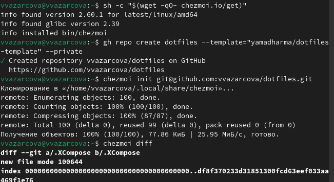

Создание и подключение репозитория dotfiles

## Использование chezmoi на нескольких машинах

Использую chezmoi на второй машине - инициализирую его с новым репозиторием и вношу изменения.

# Выводы

Мне удалось:

- Получить практические навыки работы с менеджером пароля pass
- Установить и настроить всё нужное дополнительное программное обеспечение

## Итоговый слайд

Если вам понравилось - посмотрите остальные мои презентации!